# Project: Investigate a Dataset - [Soccer Database]

- Introduction
- Data Wrangling
- Exploratory Data Analysis
- Conclusions

## Introduction

### Dataset Description

> This soccer database comes from Kaggle and is well suited for data analysis and machine learning. It contains data for soccer matches, players, and teams from several European countries from 2008 to 2016.  
> -+25,000 matches  
> -+10,000 players  
> -11 European Countries with their lead championship  
> -Seasons 2008 to 2016  
> -Players and Teams' attributes* sourced from EA Sports' FIFA video game series, including the weekly updates  
> -Detailed match events (goal types, possession, corner, cross, fouls, cards etc…) for +10,000 matches

> **Tables**  
> Country  
> League  
> Match  
> Player  
> Player_Attributes  
> Team  
> Team_Attributes

**All tables are linked with each other with ids

### Question(s) for Analysis

Q1:What are the teams most improved from 2010 to 2016?  
Q2:What are the Country with most goals over years?  
Q3:Compare the goals scored in each country in each season.  
Q4:Which side has more possibility to win a match in England?  
Q5:What are the most winning teams of all-time?  
Q6:What are the most attributes affecting victories?  
Q7:Which is the preferred foot for most players?  
Q8:What is the most age range of Players in 2016?  
Q9:What height range is the most common?  
Q10:Show the distribution of weight.  
Q11:What attributes are affected with the age of the player?  
Q12:What also affects sprint speed?  
Q13:What attributes does height affect?  
Q14:Which player had the most penalities in 2016?

```python
# Use this cell to set up import statements for all of the packages that you
#   plan to use.

# Remember to include a 'magic word' so that your visualizations are plotted
#   inline with the notebook. See this page for more:
#   http://ipython.readthedocs.io/en/stable/interactive/magics.html
import numpy as np
import pandas as pd
import sqlite3
import matplotlib.pyplot as plt
%matplotlib inline
```

## Data Wrangling

### Loading Data from SQL

*Refrence:https://www.kaggle.com/abhishektripathy/data-analysis-with-sql#List-of-Teams*

```python
# Load your data and print out a few lines. Perform operations to inspect data
#   types and look for instances of missing or possibly errant data.
conn = sqlite3.connect('database.sqlite')
countries = pd .read_sql('SELECT * FROM Country',conn)
leagues = pd.read_sql('SELECT * FROM League JOIN Country ON Country.id = League.country_id',conn)
df_t = pd.read_sql_query ('SELECT * FROM Team', conn)
players=pd.read_sql("""SELECT Player.player_name,
                                 Player.birthday,
                                 Player.height,
                                 Player.weight,
                                 date,
                                 overall_rating,
                                 potential,
                                 preferred_foot,
                                 heading_accuracy,
                                 penalties,
                                 sprint_speed
                       FROM Player_Attributes
                       JOIN Player on Player.player_api_id = Player_Attributes.player_api_id""",conn
                   )
detailed_matches = pd.read_sql("""SELECT Match.id,
                                        Country.name AS country_name,
                                        League.name AS league_name,
                                        season,
                                        date,
                                        stage,
                                        HT.team_long_name AS  home_team,
                                        AT.team_long_name AS away_team,
                                        home_team_goal,
                                        away_team_goal
                                FROM Match
                                JOIN Country on Country.id = Match.country_id
                                JOIN League on League.id = Match.league_id
                                LEFT JOIN Team AS HT on HT.team_api_id = Match.home_team_api_id
                                LEFT JOIN Team AS AT on AT.team_api_id = Match.away_team_api_id
                                ORDER by date""",conn)
df_ta =pd.read_sql_query('SELECT * FROM Team_Attributes',conn)
df=pd.merge(left=df_t , right=df_ta , how='inner',on='team_api_id')
```

### Exploring data

```python
df.shape
```

```
(1458, 29)
```

```python
df.info()
```

```
<class 'pandas.core.frame.DataFrame'>
Int64Index: 1458 entries, 0 to 1457
Data columns (total 29 columns):
 #   Column                          Non-Null Count  Dtype
---  ------                          --------------  -----
 0   id_x                            1458 non-null   int64
 1   team_api_id                     1458 non-null   int64
 2   team_fifa_api_id_x              1458 non-null   float64
 3   team_long_name                  1458 non-null   object
 4   team_short_name                 1458 non-null   object
 5   id_y                            1458 non-null   int64
 6   team_fifa_api_id_y              1458 non-null   int64
 7   date                            1458 non-null   object
 8   buildUpPlaySpeed                1458 non-null   int64
 9   buildUpPlaySpeedClass           1458 non-null   object
```

[output cut: 21 more lines]

```python
detailed_matches.shape
```

```
(25979, 10)
```

```python
detailed_matches.info()
```

```
<class 'pandas.core.frame.DataFrame'>
RangeIndex: 25979 entries, 0 to 25978
Data columns (total 10 columns):
 #   Column          Non-Null Count  Dtype
---  ------          --------------  -----
 0   id              25979 non-null  int64
 1   country_name    25979 non-null  object
 2   league_name     25979 non-null  object
 3   season          25979 non-null  object
 4   date            25979 non-null  object
 5   stage           25979 non-null  int64
 6   home_team       25979 non-null  object
 7   away_team       25979 non-null  object
 8   home_team_goal  25979 non-null  int64
 9   away_team_goal  25979 non-null  int64
dtypes: int64(4), object(6)
memory usage: 2.0+ MB
```

```python
sum(detailed_matches.duplicated())
```

```
0
```

```python
detailed_matches.describe()
```

|  | id | stage | home_team_goal | away_team_goal |
| --- | --- | --- | --- | --- |
| count | 25979.000000 | 25979.000000 | 25979.000000 | 25979.000000 |
| mean | 12990.000000 | 18.242773 | 1.544594 | 1.160938 |
| std | 7499.635658 | 10.407354 | 1.297158 | 1.142110 |
| min | 1.000000 | 1.000000 | 0.000000 | 0.000000 |
| 25% | 6495.500000 | 9.000000 | 1.000000 | 0.000000 |
| 50% | 12990.000000 | 18.000000 | 1.000000 | 1.000000 |
| 75% | 19484.500000 | 27.000000 | 2.000000 | 2.000000 |
| max | 25979.000000 | 38.000000 | 10.000000 | 9.000000 |

```python
players.shape
```

```
(183978, 11)
```

```python
players.info()
```

```
<class 'pandas.core.frame.DataFrame'>
RangeIndex: 183978 entries, 0 to 183977
Data columns (total 11 columns):
 #   Column            Non-Null Count   Dtype
---  ------            --------------   -----
 0   player_name       183978 non-null  object
 1   birthday          183978 non-null  object
 2   height            183978 non-null  float64
 3   weight            183978 non-null  int64
 4   date              183978 non-null  object
 5   overall_rating    183142 non-null  float64
 6   potential         183142 non-null  float64
 7   preferred_foot    183142 non-null  object
 8   heading_accuracy  183142 non-null  float64
 9   penalties         183142 non-null  float64
 10  sprint_speed      183142 non-null  float64
dtypes: float64(6), int64(1), object(4)
memory usage: 15.4+ MB
```

### Filtering players database with year

```python
players['date']=pd.to_datetime(players['date'])
players['date']=players['date'].dt.year
player2016=players.query('date==2016')
```

```python
player2016.head()
```

|  | player_name | birthday | height | weight | date | overall_rating | potential | preferred_foot | heading_accuracy | penalties | sprint_speed |
| --- | --- | --- | --- | --- | --- | --- | --- | --- | --- | --- | --- |
| 0 | Aaron Appindangoye | 1992-02-29 00:00:00 | 182.88 | 187 | 2016 | 67.0 | 71.0 | right | 71.0 | 48.0 | 64.0 |
| 5 | Aaron Cresswell | 1989-12-15 00:00:00 | 170.18 | 146 | 2016 | 74.0 | 76.0 | left | 58.0 | 59.0 | 78.0 |
| 6 | Aaron Cresswell | 1989-12-15 00:00:00 | 170.18 | 146 | 2016 | 74.0 | 76.0 | left | 58.0 | 59.0 | 78.0 |
| 7 | Aaron Cresswell | 1989-12-15 00:00:00 | 170.18 | 146 | 2016 | 73.0 | 75.0 | left | 57.0 | 59.0 | 78.0 |
| 38 | Aaron Doran | 1991-05-13 00:00:00 | 170.18 | 163 | 2016 | 65.0 | 67.0 | right | 60.0 | 61.0 | 74.0 |

### Data Cleaning

```python
# After discussing the structure of the data and any problems that need to be
#   cleaned, perform those cleaning steps in the second part of this section.

#Cleaning unnecessary data
droplist=[]
for i in df.columns:
    if 'Class' in i or 'id' in i:
        droplist.append(i)
df.drop(droplist,axis=1,inplace=True)
```

```python
#Filling nan values with mean and re-checking if there is any nan values
mean=df['buildUpPlayDribbling'].mean()
df['buildUpPlayDribbling'].fillna(mean,inplace=True)
df['buildUpPlayDribbling'].astype(int)
df.isnull().sum()
```

```
team_long_name            0
team_short_name           0
date                      0
buildUpPlaySpeed          0
buildUpPlayDribbling      0
buildUpPlayPassing        0
chanceCreationPassing     0
chanceCreationCrossing    0
chanceCreationShooting    0
defencePressure           0
defenceAggression         0
dtype: int64
```

```python
#Checking for duplicated rows
sum(df.duplicated())
```

```
1
```

```python
#Dropping duplicated rows
df.drop_duplicates(inplace=True)
```

```python
df.describe()
```

|  | buildUpPlaySpeed | buildUpPlayDribbling | buildUpPlayPassing | chanceCreationPassing | chanceCreationCrossing | chanceCreationShooting | defencePressure | defenceAggression |
| --- | --- | --- | --- | --- | --- | --- | --- | --- |
| count | 1457.000000 | 1457.000000 | 1457.000000 | 1457.000000 | 1457.000000 | 1457.000000 | 1457.000000 | 1457.000000 |
| mean | 52.463967 | 48.606406 | 48.489362 | 52.166781 | 53.734386 | 53.971860 | 46.017845 | 49.253946 |
| std | 11.549653 | 5.602974 | 10.899771 | 10.364195 | 11.090171 | 10.330588 | 10.230702 | 9.740734 |
| min | 20.000000 | 24.000000 | 20.000000 | 21.000000 | 20.000000 | 22.000000 | 23.000000 | 24.000000 |
| 25% | 45.000000 | 48.607362 | 40.000000 | 46.000000 | 47.000000 | 48.000000 | 39.000000 | 44.000000 |
| 50% | 52.000000 | 48.607362 | 50.000000 | 52.000000 | 53.000000 | 53.000000 | 45.000000 | 48.000000 |
| 75% | 62.000000 | 48.607362 | 55.000000 | 59.000000 | 62.000000 | 61.000000 | 51.000000 | 55.000000 |
| max | 80.000000 | 77.000000 | 80.000000 | 80.000000 | 80.000000 | 80.000000 | 72.000000 | 72.000000 |

```python
player2016.info()
```

```
<class 'pandas.core.frame.DataFrame'>
Int64Index: 14103 entries, 0 to 183904
Data columns (total 11 columns):
 #   Column            Non-Null Count  Dtype
---  ------            --------------  -----
 0   player_name       14103 non-null  object
 1   birthday          14103 non-null  object
 2   height            14103 non-null  float64
 3   weight            14103 non-null  int64
 4   date              14103 non-null  int64
 5   overall_rating    14098 non-null  float64
 6   potential         14098 non-null  float64
 7   preferred_foot    14098 non-null  object
 8   heading_accuracy  14098 non-null  float64
 9   penalties         14098 non-null  float64
 10  sprint_speed      14098 non-null  float64
dtypes: float64(6), int64(2), object(3)
memory usage: 1.3+ MB
```

```python
#Dropping nan Values
player2016=player2016.dropna()
```

```python
#Re-checking if there is any nan value
player2016.isnull().any()
```

```
player_name         False
birthday            False
height              False
weight              False
date                False
overall_rating      False
potential           False
preferred_foot      False
heading_accuracy    False
penalties           False
sprint_speed        False
dtype: bool
```

```python
#Checking for duplicates in players2016 dataframe
sum(player2016.duplicated())
```

```
4705
```

```python
#Deleting duplicates
player2016.drop_duplicates(inplace=True)
```

```python
#Checking for repeated player names
sum(player2016['player_name'].duplicated())
```

```
3855
```

```python
#Deleting duplicates for player names as they are unnecessary for the same year
player2016.drop_duplicates(subset ="player_name",inplace = True)
```

```python
player2016.info()
```

```
<class 'pandas.core.frame.DataFrame'>
Int64Index: 5538 entries, 0 to 183903
Data columns (total 11 columns):
 #   Column            Non-Null Count  Dtype
---  ------            --------------  -----
 0   player_name       5538 non-null   object
 1   birthday          5538 non-null   object
 2   height            5538 non-null   float64
 3   weight            5538 non-null   int64
 4   date              5538 non-null   int64
 5   overall_rating    5538 non-null   float64
 6   potential         5538 non-null   float64
 7   preferred_foot    5538 non-null   object
 8   heading_accuracy  5538 non-null   float64
 9   penalties         5538 non-null   float64
 10  sprint_speed      5538 non-null   float64
dtypes: float64(6), int64(2), object(3)
memory usage: 519.2+ KB
```

## Exploratory Data Analysis

```python
# Use this, and more code cells, to explore your data. Don't forget to add
#   Markdown cells to document your observations and findings.

#Getting the Overall rating of each team in each year by getting the mean of all atributes.
df['Overall']=df.mean(axis=1,numeric_only=True)
```

```python
#Converting date column to datetime format to be easier to use
df['date'] = pd.to_datetime(df['date'])
df['date']=df['date'].dt.year
```

```python
#Getting the latest and earliest year in the teams database
maxyear=df.groupby('team_long_name')['date'].max()
minyear=df.groupby('team_long_name')['date'].min()
print(maxyear.max(),minyear.min())
```

```
2015 2010
```

The earliest year was found to be 2010 and the latest 2015.

```python
df_2015=df.query('date == 2015')
or2015=df_2015.groupby('team_long_name')['Overall'].mean()
```

```python
df_2010=df.query('date == 2010')
or2010=df_2010.groupby('team_long_name')['Overall'].mean()
```

```python
mostimp=or2015-or2010
most_imp_teams=mostimp.sort_values(ascending=False)
most_imp_teams[0:5]
```

```
team_long_name
Empoli        19.92408
Sassuolo      18.42408
SL Benfica    17.54908
FC Porto      16.54908
Cagliari      15.79908
Name: Overall, dtype: float64
```

The most improved team from 2010 to 2015 was found to be Empoli

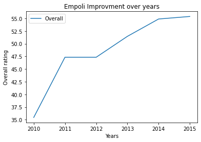

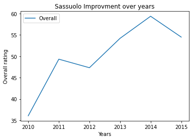

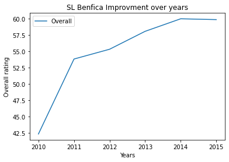

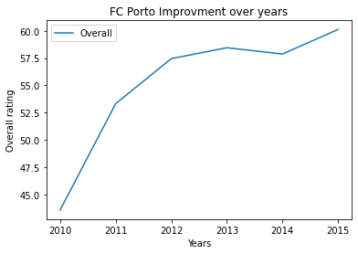

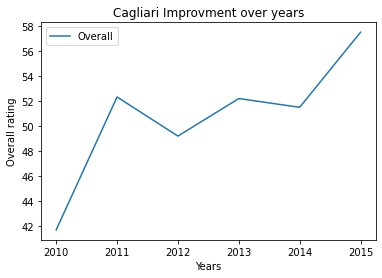

```python
#Plotting the Overall Rate of the 5 most improved teams over years.
for m in most_imp_teams.index[0:5]:
    df_most_imp=df[df['team_long_name']==m]
    df_most_imp.plot(x='date',y='Overall',title='{} Improvment over years'.format(m))
    plt.xlabel("Years")
    plt.ylabel("Overall rating");
```

These are the Overall ratings of the 5 most improved teams from 2010 to 2015 over these time interval

### Q2:What are the Country with most goals over years?

```python
# Continue to explore the data to address your additional research
#   questions. Add more headers as needed if you have more questions to
#   investigate.
#getting the total goals scored in each match
detailed_matches['Total Goals']=detailed_matches['home_team_goal']+detailed_matches['away_team_goal']
```

*Refrence:https://www.dataquest.io/blog/tutorial-add-column-pandas-dataframe-based-on-if-else-condition/*

```python
conditions = [
    (detailed_matches['home_team_goal'] > detailed_matches['away_team_goal']),
    (detailed_matches['home_team_goal'] < detailed_matches['away_team_goal']) ,
    (detailed_matches['home_team_goal'] == detailed_matches['away_team_goal'])
             ]

# create a list of the values we want to assign for each condition
values = ['Home', 'Away', 'Draw']
values1 = [detailed_matches['home_team'], detailed_matches['away_team'], 'Draw']

# create a new column and use np.select to assign values to it using our lists as arguments
detailed_matches['Win'] = np.select(conditions, values)
detailed_matches['Winner'] = np.select(conditions, values1)
```

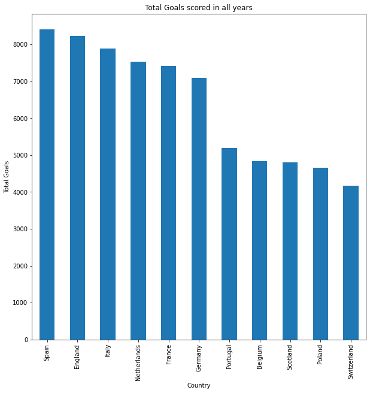

```python
goalcountry=detailed_matches.groupby(['country_name'])['Total Goals'].sum().sort_values(ascending=False)
goalcountry.plot(kind='bar',figsize=(10,10),title='Total Goals scored in all years');
plt.xlabel('Country',fontsize=10);
plt.ylabel('Total Goals',fontsize=10);
```

This plot shows the total goals scored in each country in all years.  
Spain appears to be the country with most total goals while Switzerland appears to be the lowest.

### Q3:Compare the goals scored in each country in each season.

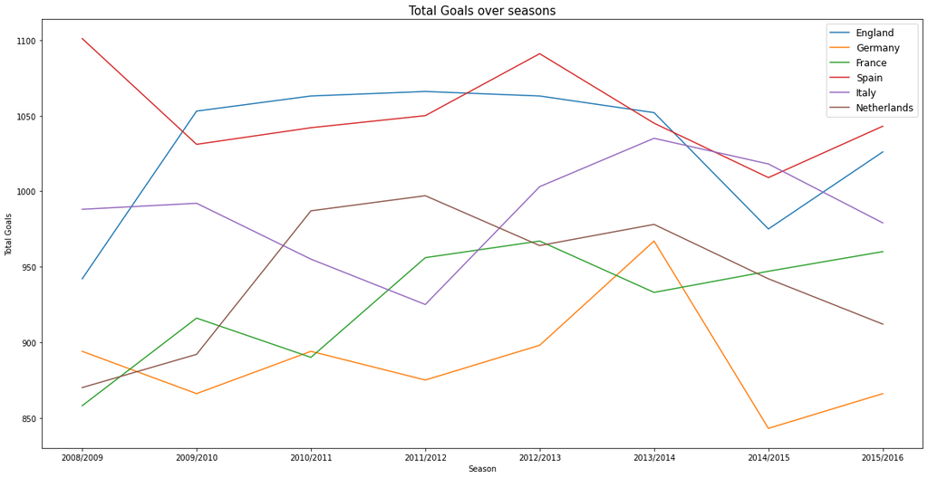

```python
#plotting goals scored in each country in each season
dm_eng=detailed_matches.query('country_name=="England"')
eng=dm_eng.groupby('season')['Total Goals'].sum()
dm_ger=detailed_matches.query('country_name=="Germany"')
ger=dm_ger.groupby('season')['Total Goals'].sum()
dm_fra=detailed_matches.query('country_name=="France"')
fra=dm_fra.groupby('season')['Total Goals'].sum()
dm_sp=detailed_matches.query('country_name=="Spain"')
sp=dm_sp.groupby('season')['Total Goals'].sum()
dm_it=detailed_matches.query('country_name=="Italy"')
it=dm_it.groupby('season')['Total Goals'].sum()
dm_ne=detailed_matches.query('country_name=="Netherlands"')
ne=dm_ne.groupby('season')['Total Goals'].sum()
eng.plot(figsize=(20,10),label='England');
ger.plot(figsize=(20,10),label='Germany');
fra.plot(figsize=(20,10),label='France');
sp.plot(figsize=(20,10),label='Spain');
it.plot(figsize=(20,10),label='Italy');
ne.plot(figsize=(20,10),label='Netherlands');
plt.title('Total Goals over seasons',fontsize=15);
plt.xlabel('Season')
plt.ylabel('Total Goals')
plt.legend(fontsize=12);
```

This plot shows the goals scored each season in each country.  
It shows that Spain has scored most goals in one season in 2008/2009 while Germany has scored the least in 2014/2015.

### Q4:Which side has more possibility to win a match in England?

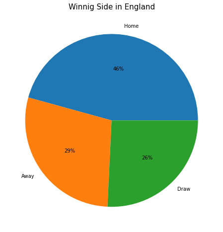

```python
eng_hg=dm_eng['Win'].value_counts()
eng_hg.plot(kind='pie',figsize=(8,8),autopct='%1.0f%%');
plt.title('Winnig Side in England',fontsize=15)
plt.ylabel('')
plt.show();
```

This pie chart shows that Home team wins 46% of all matches in England while Away team wins 29% and Draw occurs in 26% of the matches.  
This shows that Home team has more possibilities to win.

### Q5:What are the most winning teams of all-time?

```python
mostwin=detailed_matches['Winner'].value_counts().sort_values(ascending=False)
mostwinners=detailed_matches['Winner'].value_counts().sort_values(ascending=False).index
print('The most 5 Winning Teams are: \n{}'.format(mostwin[1:6]));
#index is [1:6] because index[0] is draw which is not a team
```

```
The most 5 Winning Teams are:
FC Barcelona         234
Real Madrid CF       228
Celtic               218
FC Bayern Munich     193
Manchester United    192
Name: Winner, dtype: int64
```

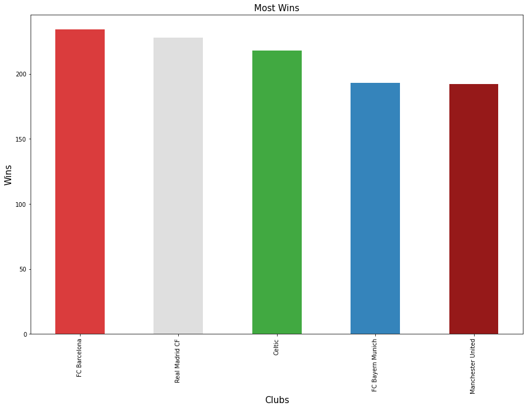

```python
mostwin[1:6].plot(kind='bar',color=['tab:red','gainsboro','tab:green','tab:blue','darkred'],alpha=0.9,figsize=(15,10))
plt.title('Most Wins',fontsize=15)
plt.xlabel('Clubs',fontsize=15)
plt.ylabel('Wins',fontsize=15)
plt.show();
```

This Bar Chart shows the 5 most winning teams over the given years.  
FC Barcelona appears to be in the 1st place.

### Q6:What are the most attributes affecting victories?

```python
df_mw=pd.DataFrame(data=mostwin)
df_mw['team_long_name']=df_mw.index
df_mw=df_mw.rename(columns={'Winner':'Wins'})
index = pd.Index(range(0, 297, 1))
df_mw.set_index(index,inplace=True)
```

```python
df_tmw=pd.merge(left=df_t , right=df_mw , how='inner',on='team_long_name')
```

```python
listr=df_ta.columns.tolist()
listr.remove('team_api_id')
df_tma=df_ta.groupby(['team_api_id'])[listr].mean()
df_tma.fillna(method='bfill',inplace=True)
```

```python
df_tmwa=pd.merge(left=df_tmw , right=df_tma , how='inner',on='team_api_id')
df_tmwa=df_tmwa.drop(columns=['id_x','team_api_id','team_fifa_api_id_x','id_y','team_fifa_api_id_y','team_long_name','team_short_name'])
```

```python
list2=df_tmwa.columns.tolist()
list2.remove('Wins')
```

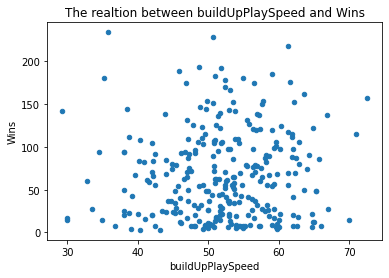

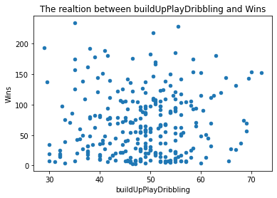

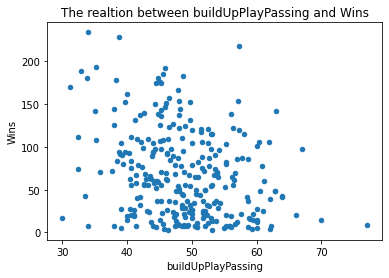

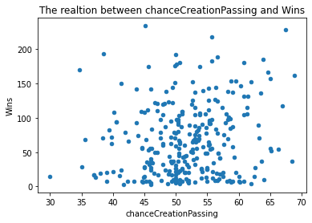

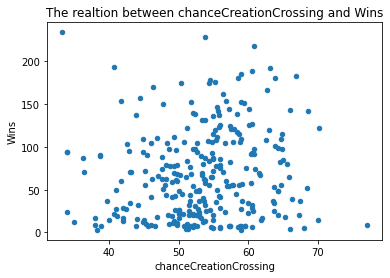

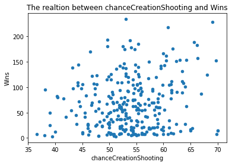

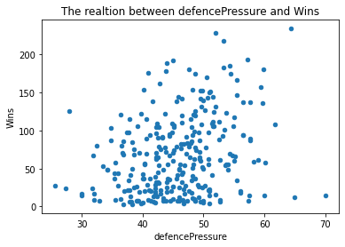

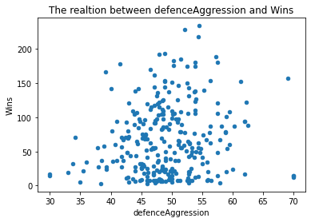

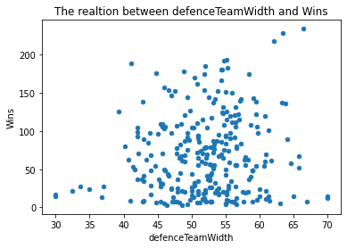

```python
for i in list2:
    x=i
    y='Wins'
    df_tmwa.plot(x,y,kind='scatter');
    plt.title("The realtion between {} and {}".format(x,y))
```

The above scatter charts shows number of attributes against number of wins to determine the relation between them.  
It appears that Attributes like 'Chance Creation Passing','Chance Creation Crossing','Chance Creation Shooting'and 'Defence Pressure' have positive correlation with number of wins.  
However,Attributes like 'Build Up Passing' seems to have negative correlation with wins.

### Q7:Which is the preferred foot for most players?

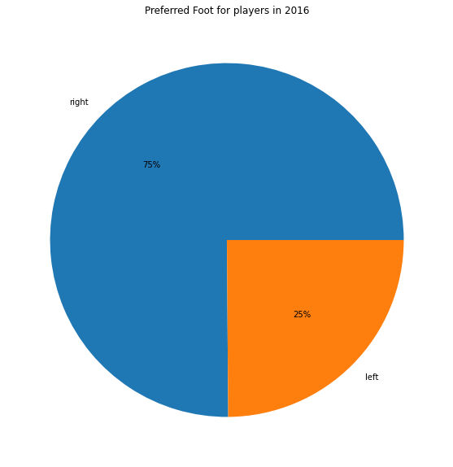

```python
Foot_Counter=player2016['preferred_foot'].value_counts()
Foot_Counter.plot(kind='pie',autopct='%1.0f%%',title='Preferred Foot for players in 2016',figsize=(10,10))
plt.ylabel('');
```

The pie chart above Shows that 75% prefer right foot while only 25% prefer the left one.

```python
#Calculating the age of the players
player2016['birthday']=pd.to_datetime(player2016['birthday'])
player2016['birth_year']=player2016['birthday'].dt.year
player2016['age']=player2016['date']-player2016['birth_year']
```

```python
def plotting_scatter(df,x,y,title,xl,yl):
    df.plot(x,y,kind='scatter');
    plt.xlabel(xl)
    plt.ylabel(yl)
    plt.title(title)
def Plotting_hist(df,x):
    df.hist(x);
    plt.xlabel(x)
    plt.title('Distribution of {}'.format(x))
```

### Q8:What is the most age range of Players in 2016?

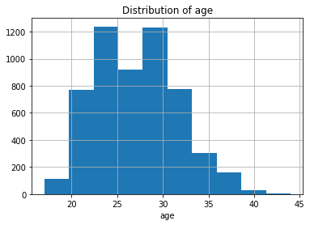

```python
Plotting_hist(player2016,'age')
```

This histogram shows the distribution of age.  
Most players appear to be from 22 to 25 and 28 to 30.

### Q9:What height range is the most common?

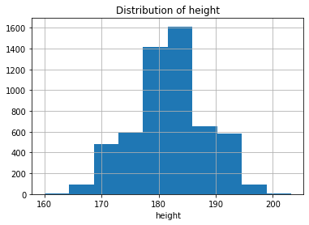

```python
Plotting_hist(player2016,'height')
```

This histogram shows the distribution of height. It is Normally distributed.  
Most players appear to be around 185 cm.

### Q10: Show the distribution of weight.

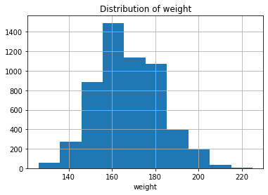

```python
Plotting_hist(player2016,'weight')
```

This histogram shows the distribution of weight.  
Most players appear to be around 160.

### Q11:What attributes are affected with the age of the player?

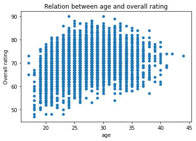

```python
plotting_scatter(player2016,'age','overall_rating','Relation between age and overall rating','age','Overall rating')
```

The scatter plot above shows the correlation between overall rating of a player and his age.  
Its obvious that the rating increases to a certain age then it begins to decrese with the age.

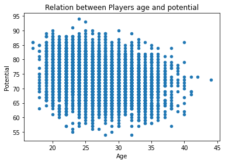

```python
plotting_scatter(player2016,'age','potential','Relation between Players age and potential','Age','Potential')
```

The scatter plot above shows the correlation between potenial of a player and his age.  
It shows that Potenial has negative correlation with age.

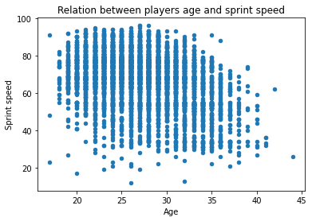

```python
plotting_scatter(player2016,'age','sprint_speed','Relation between players age and sprint speed','Age','Sprint speed')
```

The scatter plot above shows the correlation between Sprint speed of a player and his age.  
It shows that Sprint speed decreases with age.

### Q12:What also affects sprint speed?

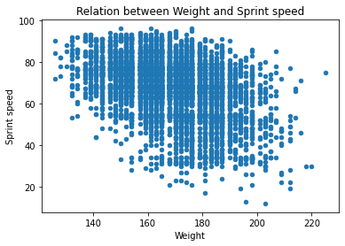

```python
plotting_scatter(player2016,'weight','sprint_speed','Relation between Weight and Sprint speed','Weight','Sprint speed')
```

The plot above shows the correlation between sprint speed and weight of the player.  
It seems to be a negative correlation.

### Q13:What attributes does height affect?

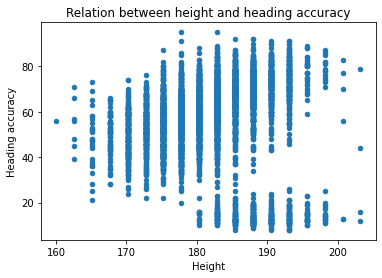

```python
plotting_scatter(player2016,'height','heading_accuracy','Relation between height and heading accuracy','Height','Heading accuracy')
```

This scatter plot represent the correlation between heading accuracy and height.  
Whenever the height increases the heading accuracy increases.

### Q14:Which player had the most penalities in 2016?

```python
most_pen=player2016['penalties'].idxmax()
print("The player with the most penalities in 2016 is :",player2016.loc[most_pen][0])
```

```
The player with the most penalities in 2016 is : Rickie Lambert
```

## Conclusions

#### Limitations

-This database is based on a sample collected between 2008 and 2016 for some of european teams and players which doesnot represent the full image of the population. This makes the analysis easier but it doesnot give a 100% accurate output but it still gives an indication.  
-Some of the data were missing so we must fill them with different methods according the data itself to start our analysis.  
-There was some duplicate rows and also multiple data for the same players in the same year in which we dealt with by keeping only the latest entry.  
-Maybe data would be better to be collected from the official sites of the leagues rather than depending on some other sites and games like 'Fifa', also the sample may be better if we had data from more leagues,teams,players and matches in more countries and over a larger period of time.

```python
from subprocess import call
call(['python', '-m', 'nbconvert', 'Investigate_a_Dataset.ipynb'])
```

```
1
```